# INFO201 Final Group Project Proposal

## [Final Project Website Link](https://kzz9.shinyapps.io/Final-Project/)

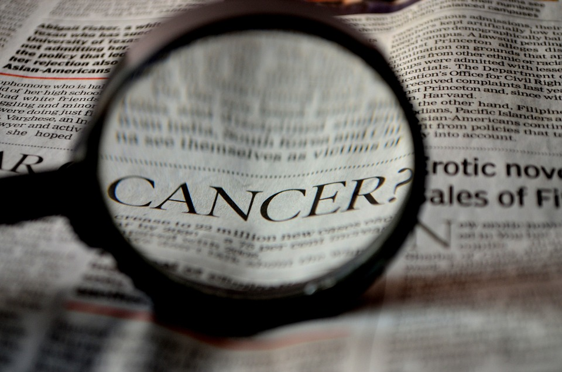

## Author:

- “Kaz Jiang”
- “Xiying(Nina) Zhang”
- “Yue(Ivy) Wu”
- “Bingyan Wang”

## Project description:

The dataset we will be working with is the **U.S. Cancer Statistics** from **1999** to **2015**, collecting information about all available *diagnosed cancer cases* and *deaths* for the **whole U.S. population**. This U.S. Cancer Statistics(*USCS*) is collected by **Centers for Disease Control and Prevention(*CDC*)**. We will use this dataset to build some visualizations and look for the possible *tendencies* between cancer and other factors like **geographical locations, genders, races and ages**, etc.  
Our target **audiences** could be professional public health staff, as well as people who are interested in cancer statistics or *suspicious* about their own health condition. The **latter** one is the audience we put *more* focuses on, since our goal is to enable the general public to figure out their own propensity of cancer dangers.

- Possible questions answer for audience:
  - How could cancer population be possibly affected by different states, years, and races?
  - Which cancer types are the most prevalence ones in U.S? Is this different in different state/years?
  - Does cancer statistics show any differences between male and female?

## Technical Description

- In the final project we will use both *API* and *csv* in order to achieve our goal. From API, we will use `httr` and `jsonlite` libraries to parse the *JSON data* from api to a R data frame. From .csv, we will just use basic read.csv function to parse the data.
- We will separate dataset to **two major groups** (*mortality* and *incident*) then sort the data in order to make *visualize* easier. Also, we will filter out the NA value in order to make dataset valid. Additionally, we will probably modify both API data and csv data in order to make a join.
- This time we will focus on libraries: `shiny`, `httr`, `jsonlite`, `ploty`, and maybe some other libraries which will make the **visualization** more efficient.
- The major **challenges**: Make a well format dataset to work with because most of cancer dataset are badly formatted. Make a beautiful visualization and also easy for client to understand. Make an **attractive R based website**.